# Project 5

STATS 220 Semester One, 2026

Yifeng Deng

2026-05-26

## Introduction

For this project, I focused on AI and digital-related communications from the New Zealand Government Beehive website. I used search terms related to “AI” and “digital” and collected more than 60 search results from multiple pages of Beehive releases and speeches. I selected this topic because I am interested in data technologies, artificial intelligence, and how governments are responding to digital transformation in areas such as health, education, and innovation.

To create my dataset, I manually saved HTML pages from the Beehive website and used ethical web scraping techniques taught in STATS 220. I also used the Wikipedia API to collect minister-related information, such as political party data. When using Beehive data, it is important to acknowledge the source, avoid excessive requests to the website, and not misuse official government material or third-party content. The main data sources used in this project were https://www.beehive.govt.nz and the Wikipedia API.

## Visualisation

The purpose of my visualisation was to explore how frequently AI and digital-related topics appeared in New Zealand government communications and how these results were associated with different political parties over time.

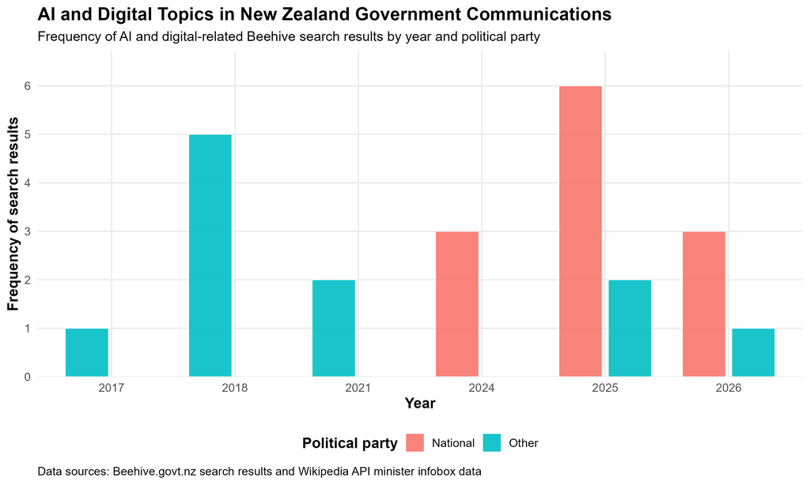

My visualisation

## Creativity

My visualisation demonstrates creativity because it combines multiple digital data sources, text analysis, and data visualisation techniques into one purpose-driven project. I combined Beehive search results with Wikipedia API data and used stringr functions to classify AI and digital-related content. Instead of only showing raw search results, I created a visualisation that explored political and technological trends in government communication. The project also connects to my personal interest in AI and data technologies, which helped guide the topic selection and analysis.

## Learning reflection

One important idea I learned from Module 5 is that creating data from digital sources requires careful planning, ethical consideration, and understanding of how websites and APIs work. Before this project, I mostly thought of websites as places to read information. Through this project, I learned how HTML structure, CSS selectors, APIs, and data cleaning techniques can be used to turn web information into analysable datasets.

I also learned that digital data is often messy and inconsistent. For example, party names from Wikipedia were written in different ways, so I needed to standardise and clean the data before analysing it. Another challenge was ensuring that the correct HTML elements were selected during web scraping. This project made me more interested in learning about automated data pipelines, large-scale web scraping, and how AI systems process online text data.

## Self review

Across the five STATS 220 projects, I believe I developed stronger skills in both data manipulation and communicating with data technologies, which are important learning outcomes of the course. One important skill I developed was the ability to source and combine data from multiple digital sources. Throughout the projects, I learned how to work with CSV files, JSON data, APIs, HTML pages, and web scraping techniques. In Project 5, I combined Beehive search results with Wikipedia API data using joins and data wrangling techniques.

A second important skill I developed was creating purpose-driven visualisations using ggplot2 and tidyverse tools. Earlier in the course, I focused mainly on getting plots to work correctly. By completing the projects, I became more aware of how data visualisations should communicate meaningful patterns clearly and effectively. I also became more confident using dplyr, stringr, joins, grouping, summarising, and text analysis to support data storytelling and communication.

## Appendix

```r
scrape_search_results <- function(page_path) {
  # Read HTML
  html_doc <- read_html(page_path)

  # Extract the isolated search result nodes (the individual cards)
  # This will depend on how you've acquired the results
  # Look for .search-result or .teaser (though there may be others)
  nodes <- html_doc %>% html_elements(".search-result")

  # Map over each individual search result
  map_df(nodes, function(node) {
    # Title
    title_element <- node %>% html_element(".views-field-title")
    title <- title_element %>% html_text2()

    # Date and time
    date_element <- node %>% html_element(".views-field-field-issue-date, time")
    datetime  <- date_element %>% html_attr("datetime") # Raw timestamp
    date_text <- date_element %>% html_text2()          # Human-readable text

    # Summary
    summary <- node %>% html_element(".views-field views-field-search-api-excerpt") %>% html_text2()

    # Ministers
    minister <- node %>%
      html_elements(".views-field-field-ministers .minister__title") %>%
      html_text2() %>%
      # trim out excess white space noise, and collapse them using a semicolon
      str_trim() %>%
      paste(collapse = ";")

    # Portfolios
    portfolio <- node %>%
      html_elements(".views-field-field-portfolios a") %>%
      html_text2() %>%
      # trim out excess white space noise, and collapse them using a semicolon
      str_trim() %>%
      paste(collapse = ";")

    # Combine individual results into a tidy tibble
    tibble(
      datetime   = datetime,
      date_text  = date_text,
      title      = title,
      ministers  = minister,
      portfolios = portfolio,
      summary    = summary
    )
  })
}
```

```r
# ------------------------------------------------------------
# Load packages
# ------------------------------------------------------------

library(tidyverse)
library(jsonlite)
library(rvest)
library(httr)

# ------------------------------------------------------------
# Beehive data: read saved HTML files
# ------------------------------------------------------------

html_files <- list.files(
  "html",
  pattern = "\\.html$",
  full.names = TRUE
)

# Load the scraping function
source("scrape_html.R")

# Apply the scraping function to each HTML file
beehive <- map_df(
  html_files,
  scrape_search_results
)

# Check for duplicate rows
nrow(beehive)
nrow(distinct(beehive))

# Remove duplicate rows if needed
beehive <- beehive %>%
  distinct()

# Save Beehive dataset locally
saveRDS(beehive, "beehive.rds")

# ------------------------------------------------------------
# Create a vector of minister names
# ------------------------------------------------------------

minister_names <- beehive %>%
  select(ministers) %>%
  separate_rows(ministers, sep = ";") %>%
  mutate(ministers = str_squish(ministers)) %>%
  filter(ministers != "") %>%
  pull(ministers) %>%
  unique()

minister_names

# ------------------------------------------------------------
# Wikipedia API data
# ------------------------------------------------------------

# Load the Wikipedia API function
source("get_wikipedia_infobox.R")

# Create ministers dataset using the Wikipedia API
# Do not run this repeatedly because it sends API requests
ministers <- map_df(
  minister_names,
  get_wikipedia_infobox
)

# Check the Wikipedia data because API matching may be imperfect
glimpse(ministers)
View(ministers)

# Check for duplicate rows
nrow(ministers)
nrow(distinct(ministers))

# Remove duplicate rows if needed
ministers <- ministers %>%
  distinct()

# Save ministers dataset locally
saveRDS(ministers, "ministers.rds")
```

```r
# ------------------------------------------------------------
# Project 5 visualisation.R
# Purpose:
# Explore how frequently AI and digital technology are mentioned
# in New Zealand government communications by year and political party.
# Data sources:
# Beehive.govt.nz search results and Wikipedia API minister data
# ------------------------------------------------------------


# ------------------------------------------------------------
# Load libraries
# ------------------------------------------------------------

library(tidyverse)
library(lubridate)


# ------------------------------------------------------------
# Read RDS files created in Part B
# ------------------------------------------------------------

beehive <- readRDS("beehive.rds")
ministers <- readRDS("ministers.rds")


# ------------------------------------------------------------
# Inspect the structure of the datasets
# ------------------------------------------------------------

glimpse(beehive)
glimpse(ministers)


# ------------------------------------------------------------
# Create a minister-party dataset from Wikipedia infobox data
# Standardise party names into National, Labour, and Other
# ------------------------------------------------------------

minister_party <- ministers %>%
  filter(label == "Party") %>%
  select(
    ministers = minister,
    party = value
  ) %>%
  mutate(
    party = case_when(
      str_detect(
        str_to_lower(party),
        "national"
      ) ~ "National",

      str_detect(
        str_to_lower(party),
        "labour"
      ) ~ "Labour",

      TRUE ~ "Other"
    )
  ) %>%
  distinct()

glimpse(minister_party)


# ------------------------------------------------------------
# Combine Beehive search results with Wikipedia minister data
# ------------------------------------------------------------

combined_data <- beehive %>%
  left_join(
    minister_party,
    by = "ministers"
  ) %>%
  mutate(
    party = ifelse(
      is.na(party),
      "Other",
      party
    )
  )

glimpse(combined_data)


# ------------------------------------------------------------
# Analyse text data using stringr and dplyr
# Detect AI and digital-related keywords in titles and summaries
# ------------------------------------------------------------

plot_data <- combined_data %>%
  mutate(
    date = dmy(date_text),

    year = year(date),

    text = str_to_lower(
      paste(title, summary)
    ),

    ai_or_digital = str_detect(
      text,
      "artificial intelligence|\\bai\\b|digital|digitisation|digitising|digitise|digitize"
    )
  ) %>%
  filter(
    !is.na(year),
    ai_or_digital
  ) %>%
  group_by(
    year,
    party
  ) %>%
  summarise(
    frequency = n()
  )

glimpse(plot_data)


# ------------------------------------------------------------
# Create purpose-driven grouped bar chart
# ------------------------------------------------------------

my_viz <- ggplot(
  data = plot_data,
  mapping = aes(
    x = factor(year),
    y = frequency,
    fill = party
  )
) +
  geom_col(
    position = position_dodge(
      width = 0.8,
      preserve = "single"
    ),
    width = 0.7,
    alpha = 0.9,
    colour = "white",
    linewidth = 0.3,
    na.rm = TRUE,
    show.legend = TRUE
  ) +
  scale_y_continuous(
    breaks = scales::pretty_breaks(n = 6),
    expand = expansion(
      mult = c(0, 0.12)
    )
  ) +
  labs(
    title = "AI and Digital Topics in New Zealand Government Communications",

    subtitle = "Frequency of AI and digital-related Beehive search results by year and political party",

    x = "Year",

    y = "Frequency of search results",

    fill = "Political party",

    caption = "Data sources: Beehive.govt.nz search results and Wikipedia API minister infobox data"
  ) +
  theme_minimal(
    base_size = 13
  ) +
  theme(
    plot.title = element_text(
      face = "bold",
      size = 16
    ),

    plot.subtitle = element_text(
      size = 12
    ),

    axis.title.x = element_text(
      face = "bold"
    ),

    axis.title.y = element_text(
      face = "bold"
    ),

    legend.position = "bottom",

    legend.title = element_text(
      face = "bold"
    ),

    panel.grid.minor = element_blank(),

    plot.caption = element_text(
      hjust = 0
    )
  )

my_viz


# ------------------------------------------------------------
# Save visualisation
# ------------------------------------------------------------

ggsave(
  filename = "my_viz.png",
  plot = my_viz,
  width = 10,
  height = 6,
  units = "in",
  dpi = 300
)
```